# House Prices: Advanced Regression Techniques - Model 1

## Content

- 1. Problem Statement
- 1. Getting Familiar with the Data
- 1. Microsoft Azure for Data Correlation
- 1. Exploratory Data Analysis
- 1. Input Missing Values
- 1. Feature Engineering
- 1. Modelling
- 1. Conclusion

# 1. Problem Statement

- **Build a regression model to predict the sales price for each house in Ames, Iowa**
  - Output Variable: The Predicted SalePrice of a house

## 1.1 About The Data

- There are **79 variables** which is a lot.
  - Should **find out which variable have the strongest correlation (predictive power) with SalePrice** and build a model based on them
  - **Beaware of variables that are correlated with each other** -> Should include just 1 of them

## 1.2 Lessons Learnt From Titanic

- Spent too much time on feature enginerring and not aware of how each step taken affects the final score.
- More often than not, it does little to improve the accuracy, or even negatively impact the score.

# 2. Getting Familar with the Data

```python
#Do the necessary imports
import numpy as np
import pandas as pd
import matplotlib.pyplot as plt
import seaborn as sns

#For comparison with normal distribution when plotting graph
from scipy.stats import norm, skew

#Encoder
from sklearn.preprocessing import LabelEncoder

#Scaler
from sklearn.preprocessing import RobustScaler

#Hide warnings
import warnings
warnings.filterwarnings('ignore')

#Make the graphs generated by matplotlib appear instead of object
%matplotlib inline

pd.set_option('display.max_columns', 500)
```

```python
#Read the data
train = pd.read_csv('./house_train.csv')
test = pd.read_csv('./house_test.csv')

print("Train data contains {0[0]} records and {0[1]} variables".format(train.shape))
print("Test data contains {0[0]} records and {0[1]} variables".format(test.shape))
```

```
Train data contains 1460 records and 81 variables
Test data contains 1459 records and 80 variables
```

```python
#Get to know the columns
train.head(3)
```

|  | Id | MSSubClass | MSZoning | LotFrontage | LotArea | Street | Alley | LotShape | LandContour | Utilities | LotConfig | LandSlope | Neighborhood | Condition1 | Condition2 | BldgType | HouseStyle | OverallQual | OverallCond | YearBuilt | YearRemodAdd | RoofStyle | RoofMatl | Exterior1st | Exterior2nd | MasVnrType | MasVnrArea | ExterQual | ExterCond | … |
| --- | --- | --- | --- | --- | --- | --- | --- | --- | --- | --- | --- | --- | --- | --- | --- | --- | --- | --- | --- | --- | --- | --- | --- | --- | --- | --- | --- | --- | --- | --- |
| 0 | 1 | 60 | RL | 65.0 | 8450 | Pave | NaN | Reg | Lvl | AllPub | Inside | Gtl | CollgCr | Norm | Norm | 1Fam | 2Story | 7 | 5 | 2003 | 2003 | Gable | CompShg | VinylSd | VinylSd | BrkFace | 196.0 | Gd | TA | … |
| 1 | 2 | 20 | RL | 80.0 | 9600 | Pave | NaN | Reg | Lvl | AllPub | FR2 | Gtl | Veenker | Feedr | Norm | 1Fam | 1Story | 6 | 8 | 1976 | 1976 | Gable | CompShg | MetalSd | MetalSd | None | 0.0 | TA | TA | … |
| 2 | 3 | 60 | RL | 68.0 | 11250 | Pave | NaN | IR1 | Lvl | AllPub | Inside | Gtl | CollgCr | Norm | Norm | 1Fam | 2Story | 7 | 5 | 2001 | 2002 | Gable | CompShg | VinylSd | VinylSd | BrkFace | 162.0 | Gd | TA | … |

```python
#Drop the Id column for both train and test
train.drop("Id", axis=1, inplace=True)
test_ID = test['Id']
test.drop("Id", axis=1, inplace=True)

#Get to know the columns' datatype and missing values
train.info()
```

```
<class 'pandas.core.frame.DataFrame'>
RangeIndex: 1460 entries, 0 to 1459
Data columns (total 80 columns):
MSSubClass       1460 non-null int64
MSZoning         1460 non-null object
LotFrontage      1201 non-null float64
LotArea          1460 non-null int64
Street           1460 non-null object
Alley            91 non-null object
LotShape         1460 non-null object
LandContour      1460 non-null object
Utilities        1460 non-null object
LotConfig        1460 non-null object
LandSlope        1460 non-null object
Neighborhood     1460 non-null object
Condition1       1460 non-null object
Condition2       1460 non-null object
BldgType         1460 non-null object
HouseStyle       1460 non-null object
OverallQual      1460 non-null int64
OverallCond      1460 non-null int64
YearBuilt        1460 non-null int64
YearRemodAdd     1460 non-null int64
RoofStyle        1460 non-null object
RoofMatl         1460 non-null object
Exterior1st      1460 non-null object
Exterior2nd      1460 non-null object
MasVnrType       1452 non-null object
MasVnrArea       1452 non-null float64
ExterQual        1460 non-null object
ExterCond        1460 non-null object
Foundation       1460 non-null object
BsmtQual         1423 non-null object
BsmtCond         1423 non-null object
BsmtExposure     1422 non-null object
BsmtFinType1     1423 non-null object
BsmtFinSF1       1460 non-null int64
BsmtFinType2     1422 non-null object
BsmtFinSF2       1460 non-null int64
BsmtUnfSF        1460 non-null int64
```

[output cut: 30 more lines]

```
EnclosedPorch    1460 non-null int64
3SsnPorch        1460 non-null int64
ScreenPorch      1460 non-null int64
PoolArea         1460 non-null int64
PoolQC           7 non-null object
Fence            281 non-null object
MiscFeature      54 non-null object
MiscVal          1460 non-null int64
MoSold           1460 non-null int64
YrSold           1460 non-null int64
SaleType         1460 non-null object
SaleCondition    1460 non-null object
SalePrice        1460 non-null int64
dtypes: float64(3), int64(34), object(43)
memory usage: 912.6+ KB
```

Comment:

- So many variables! **But when we think about our dream house, what do we care the most?**
  - **Area?** - Variables: GrLivArea, 1stFlrSF, 2ndFlrSF, TotalBsmtSF, GarageArea ...
  - **Environment?** - Variables: Neighborhood, LandSlope ...
  - **Condition of the house?** - Variables: OverallQual, GarageCond, BsmtCond ...
- Just by glancing through the columns, I picked up a few variables that I thought it would be important when buying a house
  - Sometime **intuition** helps

## 2.1 Target - SalePrice

- Let's first know a little bit more about the most important variable - our target, SalePrice

```python
#Statistics Summary of SalePrice
train['SalePrice'].describe()
```

```
count      1460.000000
mean     180921.195890
std       79442.502883
min       34900.000000
25%      129975.000000
50%      163000.000000
75%      214000.000000
max      755000.000000
Name: SalePrice, dtype: float64
```

```
Skewness of SalePrice: 1.8828757597682129
```

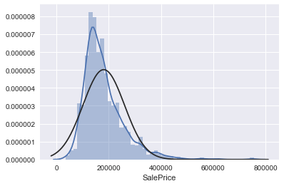

```python
#Plot the distribution graph of SalePrice
sns.distplot(train['SalePrice'], fit=norm)

#Calculate the skewness of SalePrice
print("Skewness of SalePrice: {}".format(train['SalePrice'].skew()))
```

Comment:

- SalePrice **is not a normal distribution**
  - **What is a Normal Distribution?**
    - Mean at the peak - most of the observations cluster around the central peak
    - Probabilities for values further away from the mean taper off equally in both directions
- SalePrice is **skewed to the right**
  - Mean on the right of the peak
  - Mass distribution is on the left of the mean
  - Most houses have prices around the mean of 180921.00
  - But a few houses have very high prices

Note:

- If encountered error of float index not supported when plotting graph - must upgrade numpy

  ```
  conda uninstall statsmodels --yes
  conda install -c taugspurger statsmodels=0.8.0
  ```

# 3. Microsoft Azure for Feature Selection

- Azure provides amazing tools for Machine Learning with user-friendly interface
- It allows us to quickly explore on a given dataset and build a model, without spending too much time into coding, unlike sklearn
- Use Azure's **"Filter Based Feature Selection"** to find out the **top 10 numeric variables** that have the strongest correlation with SalePrice
  - Helps to narrow down the numeric variables for data analysis later

[figure not shown]

- **Top 10 numeric variables**: *OverallQual, GrLivArea, GarageCars, GarageArea, TotalBsmtSF, 1stFlrSF, FullBath, TotRmsAbvGrd, YearBuilt, YearRemodAdd*
- **GrLivArea, TotalBsmtSF, 1stFlrSF** reflects the **area** of the house
  - This is inline with my intuition above
- **GarageCars and GarageArea are twin brothers**
  - Both reflect the **size of garage**
  - Keep GarageCars since its correlation is higher
- Notice there are **Numeric variables that are suppose to be Categorical**: OverallQual, GarageCars, FullBath, TotRmsAbvGrd, YearBuilt, YearRemodAdd
  - Need to **distinguish numeric categorical variables** and **analyse them separately**

[figure not shown]

- Run Filter Based Feature Selection again with **Chai Square to include categorical variables**
- **Top 10 Categorical Features**: *Neighborhood, BsmtQual, ExterQual, KitchenQual, GarageFinish, GarageType, FireplaceQu, Foundation, Exterior2nd, Exterior1st*
  - Neighbourhood appeared. Intuition at work again

How to analyze **data coorelation using Python?**:

```
corr_matrix = train.corr()
sns.heatmap(corr_matrix, vmax=0.8, square=True)
```

- corr_matrix is a dataframe with rows=columns=features -> Sqaure matrix
- Each feature's correlation with every other feature are computed
- The correlations can be visualized with seaborn's heat map

# 4. Exploratory Data Analysis

- Explore the relationship between **SalePrice** and:
  - **Numeric** variables: *GrLivArea, 1stFlrSF, TotalBsmtSF*
  - **Ordinal Categorical** variables: *OverallQual, GarageCars, FullBath, TotRmsAbvGrd, YearBuilt, YearRemodAdd, BsmtQual, ExterQual, KitchenQual, GarageFinish, FireplaceQu*
  - **Nominal Categorical** variables: *Neignbourhood, GarageType, Foundation, Exterior2nd, Exterior1st*

## 4.1 Relatonship with Numeric Variables

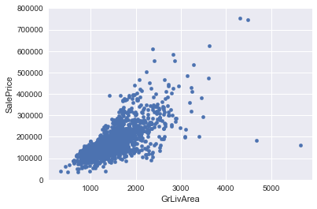

```python
#Scatter plot of GrLivArea against SalePrice
train.plot.scatter(x='GrLivArea', y='SalePrice', ylim=(0,800000))
```

Comment:

- There is a **positive linear relationship** between GrLivArea and SalePrice
- There are **two outliers**; Huge GrLivArea but low SalePrice.
  - Most likely they are **houses beside agriculture farm** since **Iowa's main industry is agriculture**
  - We need to **remove them since outliers affect regression model greatly**

### Remove Outliers

```python
#Drop outliers identified
train.drop(train[(train['GrLivArea'] > 4000) & (train['SalePrice'] < 300000)].index, inplace=True)
```

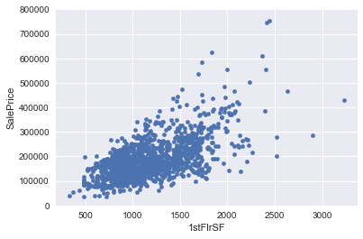

```python
#Scatter plot of 1stFlrSF against SalePrice
train.plot.scatter(x='1stFlrSF', y='SalePrice', ylim=(0,800000))
```

Comment:

- Again, 1stFlrSF has a positive relationship with SalePrice; not as strong as GrvLivArea
- I am aware that **GrLivArea = 1stFlrSF + 2ndFlrSF + LowQualFinSF**, and GrLivArea covers 1stFlrSF
  - However, I have tried **building model with and without 1stFlrSF, 1stFlrSF does improve the score**
  - Buying a house is an important decision, every detail matters. Even the total living area may be big, but if your 1stFlrSF is small and you have a huge LowQualFinSF, the SalePrice is unlikely to be high

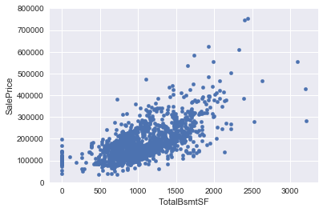

```python
#Scatter plot of TotalBsmtSF against SalePrice
train.plot.scatter(x='TotalBsmtSF', y='SalePrice', ylim=(0,800000))
```

Comment:

- TotalBsmtSF has a postive relationship with SalePrice
- However, notice **when a house has no basement, TotalBsmtSF is not related to SalePrice at all**
  - Let's engineer a feature of TotalArea = 1stFlrSF + 2ndFlrSF + TotalBsmtSF to solve this problem

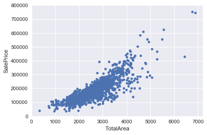

```python
train['TotalArea'] = train['1stFlrSF'] + train['2ndFlrSF'] + train['TotalBsmtSF']
#Scatter plot of TotalArea against SalePrice
train.plot.scatter(x='TotalArea', y='SalePrice', ylim=(0,800000))
```

Comment:

- TotalArea seems to have a good postive linear relationship with SalePrice, **while taking basement into account**

## 4.2 Relationship with Ordinal Categorical Variables

- Ordinal Categorical variables: OverallQual, GarageCars, FullBath, TotRmsAbvGrd, YearBuilt, YearRemodAdd, BsmtQual, ExterQual, KitchenQual, GarageFinish, FireplaceQu

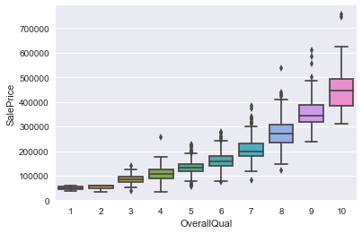

```python
#Box plot of GarageCars Against SalePrice
sns.boxplot(x='OverallQual', y='SalePrice', data=train)
```

Comment:

- The higher the OverallQual, the higher the SalePrice, which is logical
- **Ordinal Categorical variables are often correlated with SalePrice and helps the regression model to better predict the SalePrice**
  - For instance, a house with OverallQual 8 is within that price range which the model should consider
- How to **interpret a box plot**?

[figure not shown]

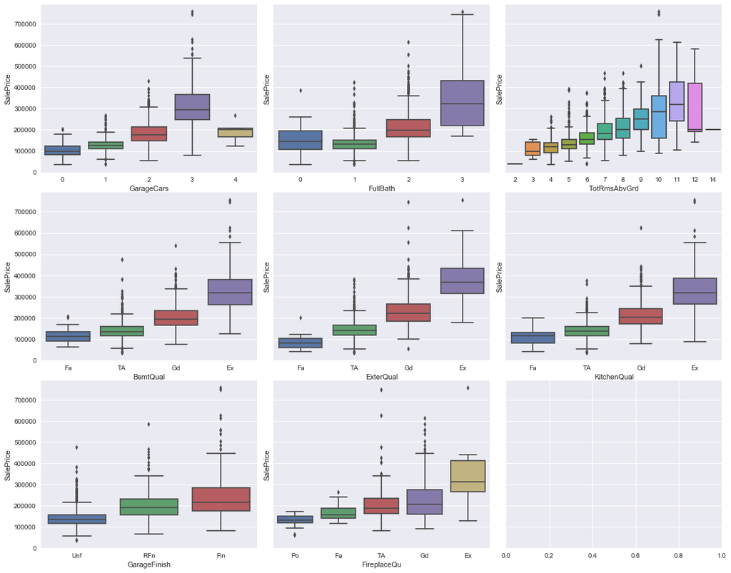

```python
#Plot the graph for the rest of ordinal categorical variables
ordinal_cat = ['GarageCars', 'FullBath', 'TotRmsAbvGrd', 'YearBuilt','YearRemodAdd', 'BsmtQual', 'ExterQual',
               'KitchenQual', 'GarageFinish', 'FireplaceQu']

fig, axs = plt.subplots(3,3, sharey=True, figsize=(15,12))
plt.tight_layout()
for i, col in enumerate([x for x in ordinal_cat if x not in ('YearBuilt', 'YearRemodAdd')]):
    if i//3 == 1:
        sns.boxplot(x=col, y='SalePrice', data=train, ax=axs[i//3, i%3], order=['Fa','TA','Gd','Ex'])
    elif i//3 ==2 and i%3 == 0:
        sns.boxplot(x=col, y='SalePrice', data=train, ax=axs[i//3, i%3], order=['Unf','RFn','Fin'])
    elif i//3 == 2:
        sns.boxplot(x=col, y='SalePrice', data=train, ax=axs[i//3, i%3], order=['Po','Fa','TA','Gd','Ex'])
    else:
        sns.boxplot(x=col, y='SalePrice', data=train, ax=axs[i//3, i%3])
```

Comment:

- Generally, ordinal categorical features show a positive relationship with SalePrice
  - Po < Fa < Ta < Gd < Ex
- However, for GarageCars=4, the SalePrice is not as expected
  - After a closer look at the **data with 4 GarageCars** (train[train['GarageCars']==4]), **just 5 of them**
  - They have **TotalArea ranging 1730 to 3882 SF, which plays a much more decisive role in their SalePrice**
  - It is **no point to have a huge Garage while your house's living area is small**
  - A buyer will consider Living Area before Garage. **It is essential to have Garage, but when it is too big, it becomes irrelevant**
  - Therefore, our model should build **considering Garage Cars with 3 or less**
  - Any house with **GarageCars > 3**, **other features will play a critical role in determining the price**
- There is also an **outlier in TotRmsAbvGrd**
  - A house with **14 rooms** and with low SalePrice. Let's **Remove** that

```python
#Drop Data with GarageCars 4 or more
train.drop(train[(train['GarageCars'] > 3)].index, inplace=True)

#Drop Data with TotRmsAbvGrd = 14
train.drop(train[(train['TotRmsAbvGrd'] == 14)].index, inplace=True)
```

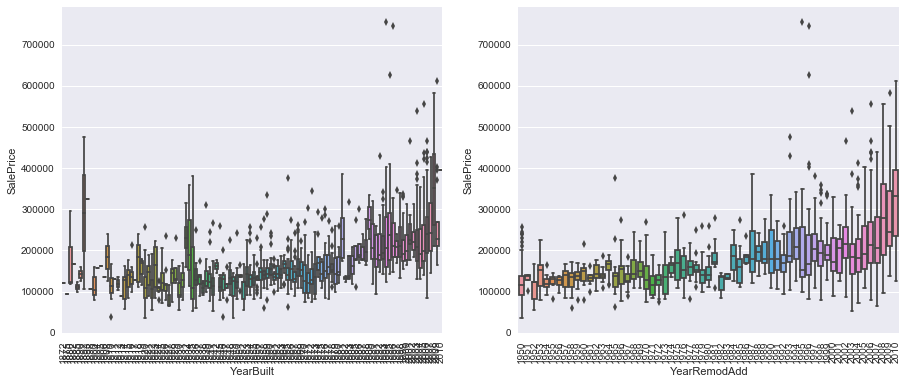

```python
#Box-plot of YearBuilt, YearRemodAdd against SalePrice
fig, axs = plt.subplots(1,2, figsize=(15,6))
sns.boxplot(x='YearBuilt', y='SalePrice', data=train, ax=axs[0])
sns.boxplot(x='YearRemodAdd', y='SalePrice', data=train, ax=axs[1])
#Rotate x-axis labels in each subplot
for ax in axs.flat:
    plt.setp(ax.get_xticklabels(), rotation=90)
```

Comment:

- **The later the house was built or rennovated, the higher the SalePrice**
- Both will likely to be considered by buyers and affected the condition of the house, we shall keep both

## 4.3 Relationship with Nominal Categorical Variables

- Nominal Categorical variables: Neigborhood, GarageType, Foundation, Exterior2nd, Exterior1st

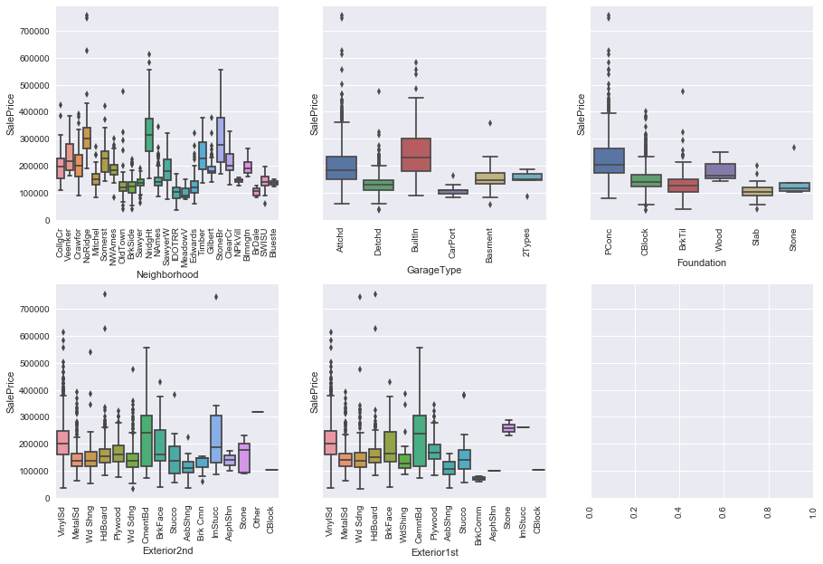

```python
nominal_cat = ['Neighborhood', 'GarageType', 'Foundation', 'Exterior2nd', 'Exterior1st']

#Box-plot of all nominal categorical features against Features
fig, axs = plt.subplots(2,3, sharey=True, figsize=(15,10))
plt.subplots_adjust(hspace=0.3)
for i, col in enumerate(nominal_cat):
    sns.boxplot(x=col, y='SalePrice', data=train, ax=axs[i//3, i%3])
for ax in axs.flat:
    plt.setp(ax.get_xticklabels(), rotation=90)
```

Comment:

- For **Neighborhood** - houses in "Nridght" generally have higher SalePrice than houses in "Sawyer"
  - So, the **location of your house really play a part in determing the SalePrice**
- For **GarageType**, people prefer "Builtin" over "CarPort"
- For **Foundation**, houses with "PCone" have higher SalePrice than "Stone"
- From data dictionary:
  - Exterior1st - Exterior covering on house
  - Exterior2nd - Exterior covering on house (if more than one material)
  - Going to **keep both of them as exteriors of the house matters and they reinforce ExterQual above**

```python
#Final selected features
features = ['GrLivArea','1stFlrSF', 'TotalBsmtSF', 'TotalArea', 'OverallQual', 'GarageCars', 'FullBath', 'TotRmsAbvGrd',
            'YearBuilt', 'YearRemodAdd', 'BsmtQual', 'ExterQual', 'KitchenQual', 'GarageFinish', 'FireplaceQu',
            'Neighborhood', 'GarageType', 'Foundation', 'Exterior1st', 'Exterior2nd']

#Get them in a separate dataframe
features_df = train[features + ['SalePrice']]

#Do the same for test data
test['TotalBsmtSF'].fillna(0, inplace=True)
test['TotalArea'] = test['1stFlrSF'] + test['2ndFlrSF'] + test['TotalBsmtSF']
test_df = test[features]
```

# 5. Input Missing Values

- First, get an overview of all missing data in each column by computing the:
  - Number of missing data
  - Percentage of missing data

```python
#Missing Values for Training Data
total = features_df.isnull().sum()
percent = (total / features_df.shape[0]) * 100
missing_data = pd.concat([total, percent], axis=1, keys=['Total', 'Percent'])
missing_data.drop(missing_data[missing_data['Total'] == 0].index).sort_values('Total',ascending=False)
```

|  | Total | Percent |
| --- | --- | --- |
| FireplaceQu | 686 | 47.245179 |
| GarageFinish | 80 | 5.509642 |
| GarageType | 80 | 5.509642 |
| BsmtQual | 37 | 2.548209 |

```python
#Missing Values for Test Data
total = test_df.isnull().sum()
percent = (total / test_df.shape[0]) * 100
missing_data = pd.concat([total, percent], axis=1, keys=['Total', 'Percent'])
missing_data.drop(missing_data[missing_data['Total'] == 0].index).sort_values('Total',ascending=False)
```

|  | Total | Percent |
| --- | --- | --- |
| FireplaceQu | 730 | 50.034270 |
| GarageFinish | 78 | 5.346127 |
| GarageType | 76 | 5.209047 |
| BsmtQual | 44 | 3.015764 |
| GarageCars | 1 | 0.068540 |
| KitchenQual | 1 | 0.068540 |
| Exterior1st | 1 | 0.068540 |
| Exterior2nd | 1 | 0.068540 |

Comment:

- **Go through features with missing values one by one and impute the most logical missing value**

```python
#FireplaceQu: If missing, the house has no Fireplace -> Fill None
features_df['FireplaceQu'].fillna('None', inplace=True)
test_df['FireplaceQu'].fillna('None', inplace=True)

#GarageType, GarageFinish: If missing, means no Garage -> Fill with None
for col in ('GarageType', 'GarageFinish'):
    features_df[col].fillna('None', inplace=True)
    test_df[col].fillna('None', inplace=True)

#BsmtQual: If missing, means no basement -> Fill with None
features_df['BsmtQual'].fillna('None', inplace=True)
test_df['BsmtQual'].fillna('None', inplace=True)

#GarageCars: If missing, means no Garage -> Fill with 0
test_df['GarageCars'].fillna(0, inplace=True)

#KitchenQual, Exterior1st, Exterior2nd: If missing, Fill with with the most common
test_df['KitchenQual'].fillna(test_df['KitchenQual'].mode()[0], inplace=True)
test_df['Exterior1st'].fillna(test_df['Exterior1st'].mode()[0], inplace=True)
test_df['Exterior2nd'].fillna(test_df['Exterior2nd'].mode()[0], inplace=True)

#Check if there are anymore missing values
features_df.isnull().values.sum() + test_df.isnull().values.sum()
```

```
0
```

# 6. Feature Engineering

- In this section, we are going to explore log transformation on numeric features, encode ordinal categorical features, and finally encode the nominal categorical features

## 6.1 Log Transformation

- In Section 2.1, we have already discovered that SalePrice is not normally distributed and it is skewed positively
- In **Machine Learning, many models such as Linear, Lasso, Ridge Regression models assume the input data is normally distributed**
  - Note: For tree-based models, data does not need to be normally distributed
- If we **do not normalize our data, the prediction made by such models will not be accurate** as the probability of finding most occurance will not be at the mean but higher or lower than the mean
- One way **to normalize data is to take the log() of the data**
  - Normalization also **reduces the effect of outliers** in this case, **rendering a more linear relationship between the features and SalePrice**
- Reference: https://stats.stackexchange.com/questions/298/in-linear-regression-when-is-it-appropriate-to-use-the-log-of-an-independent-va

### Log Transformation on SalePrice

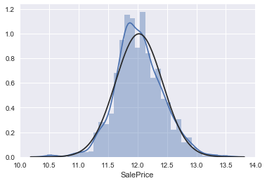

```python
#Log Transformation of SalePrice in feature_df
train['SalePrice'] = np.log1p(train['SalePrice'])

#Explore the effect of log transformation on SalePrice's normality
sns.distplot(train['SalePrice'], fit=norm)
```

Comment:

- SalePrice is more normally distributed compared to the graph in Section 2.1

### Log Transformation on GrLivArea

```
Skewness of GrLivArea:0.9990190345995116
```

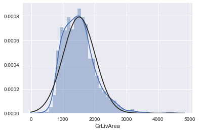

```python
#Plot the distribution graph GrLivArea
sns.distplot(train['GrLivArea'], fit=norm)
print("Skewness of GrLivArea:{}".format(skew(train['GrLivArea'])))
```

Before Log Transformation:

- Not normally distributed
- Postively skewed at 0.999

```
Skewness of GrLivArea after log transformation:-0.08058901868450259
```

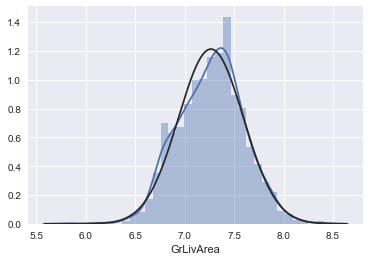

```python
#Apply log transformation to GrLivArea
train['GrLivArea'] = np.log1p(train['GrLivArea'])
print("Skewness of GrLivArea after log transformation:{}".format(skew(train['GrLivArea'])))

#Distribution ploit of GrLivArea again
sns.distplot(train['GrLivArea'], fit=norm)
```

After Log Transformation:

- More normally distributed
- Reduced skewness at -0.0805

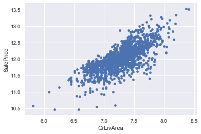

```python
#Scatterplot for GrLivArea after Log Transformation
train.plot.scatter(x='GrLivArea', y='SalePrice')
```

Comment:

- Not only log function transformed GrLivArea to be more normally distributed, it also **solves the problem of homoscedasticity**
  - Homoscedasticity: Dependent variable exhibits equal levels of variance across the range of predictor variable
- **Compared the to the scatter plot in Section 4.1 which was more dispersed at large GrLivArea values, after normalization, values of GrLivArea are more closely together; lesser variance**
- We are going to **apply log transformation to all numeric and ordinal categorical features which have skewness greater than 0.5**
  - As a general rule of thumb, a skewness with an absolute value > 0.5 is considered moderately skewed
  - Reference: https://www.kaggle.com/juliencs/a-study-on-regression-applied-to-the-ames-dataset

## 6.2 Encode Ordinal Categorical Features

```python
object_ordinal_features = ['BsmtQual', 'ExterQual', 'KitchenQual', 'GarageFinish', 'FireplaceQu' ]

#Encode ordinal cat variables which are object type using LabelEncoder
label = LabelEncoder()
for col in object_ordinal_features:
    features_df[col] = label.fit_transform(features_df[col])
    test_df[col] = label.transform(test_df[col])
```

Comment:

- Label Encoding rather than get dummy to **retain the information in the order of ordinal categorical variables**

```python
# Log the SalePrice so that the errors in predicting expensive houses and cheap houses will affect the accuracy equally
y = np.log1p(features_df['SalePrice'])
features_df.drop(['SalePrice'], axis=1, inplace=True)
```

## 6.3 Log Transformation of Numeric and Ordinal Cat Features

- Log transformation **based on skewness of Train data only**
- **In reality, after model is built, we can only log the features in Test data based on which features were logged in Train data when we were building the model**

```python
#Select all the numeric features
num_feats = features_df.select_dtypes(exclude='object').columns

#Calculate the skewness of each num feature
skewness = features_df[num_feats].apply(lambda x : skew(x)).sort_values(ascending=False)

skewness
```

```
GrLivArea       0.999019
1stFlrSF        0.891922
TotalArea       0.808613
TotRmsAbvGrd    0.603533
TotalBsmtSF     0.515659
FireplaceQu     0.301466
OverallQual     0.200895
FullBath        0.031094
GarageCars     -0.420410
BsmtQual       -0.492576
YearRemodAdd   -0.501615
YearBuilt      -0.604843
GarageFinish   -0.623149
KitchenQual    -1.425340
ExterQual      -1.828531
dtype: float64
```

```python
#Get columns with skewness > 0.5
skew_feats = skewness[abs(skewness) > 0.5].index

#Apply log transform to those with skewness > 0.5
features_df[skew_feats] = np.log1p(features_df[skew_feats])

#Apply log transform to Test base on the skewed features in Train
test_df[skew_feats] = np.log1p(test_df[skew_feats])
```

## 6.4 Encode Nominal Cat Features

```python
#Must combine to get dummies because there are options in Exterior1st/2nd in Train, not in Test
#If get dummy separately, will result in different number of features
all_df = pd.concat([features_df, test_df], axis=0)

all_df = pd.get_dummies(all_df)

features_df = all_df[:features_df.shape[0]]
test_df = all_df[features_df.shape[0]:]

print(features_df.shape)
print(test_df.shape)
```

```
(1452, 84)
(1459, 84)
```

## 6.5 Scaling the Features

```python
#RobustScaler
scaler = RobustScaler()
X = scaler.fit_transform(features_df)
X_test = scaler.transform(test_df)
```

Comment:

- **RobustScaler** scale features using statistic techniques that are **more robust to outliers** than StandardScaler
  - Reference: https://scikit-learn.org/stable/modules/generated/sklearn.preprocessing.RobustScaler.html

# 7. Modelling

- **Linear Regression** is a model that tries to **model a linear relationship between the dependent variable (SalePrice)** and **one or more independent variables (features)**
  - Only 1 independent variable - Simple Linear Regression
  - More than 1 indepedent variable - Multiple Linear Regression
- **Equation of Multiple Linear Regression:** y(x) = b + b1(x1) + b2(x2) + b3(x3) + ...
  - x1, x2 ... are different features
  - b, b1, ... are coeff of features
- From the linear regression equation above, the **coeff of each feature determines how much that feature contributes to the final value of target**
  - The **coeffs are calculated by the linear regression model to best fit the train data; which kinds of indicate the importance of the feature**
- Reference: https://www.coursera.org/lecture/machine-learning/features-and-polynomial-regression-Rqgfz
- After thorough research, I came across **Regularization techniques** in Linear Regression
  - Regularzation is often **useful** when you have **a large number of features in the dataset.** Especially for Ames Dataset.
  - It can effectively prevent over-fitting by **introducing penalize terms to features**, so to reduce any extreme weights (coeffs of features) and hence stop any feature from dominating
  - Another good thing is that the models which use regularization can **automatically select features** which help to predict the target
- There are 2 levels of Regularization:
  - **L1 Regularization**, known as **Lasso Regression**
  - **L2 Regularization**, known as **Ridge Regression**
- They **differ by penalizing terms** introduced to the features in the Linear Regression Equation
  - Lasso' penalizing terms take the sum of absolute values of feature coeffs, **shrinking the less important features's coeff to 0**, removing them from the model - **Feature Selection**
  - Ridge's penalizing terms, on the other hand, **take the square sum of the coeffs of the features**, and as a result, Ridge often **uses all the terms**
- Reference: https://towardsdatascience.com/l1-and-l2-regularization-methods-ce25e7fc831c

## 7.1 Evaluation of Models

```python
#Scorer & Cross-Validation
from sklearn.metrics import mean_squared_error
from sklearn.model_selection import KFold, cross_val_score

#Models
from sklearn.linear_model import LinearRegression, LassoCV, RidgeCV
from sklearn.ensemble import RandomForestRegressor
```

```python
#Cross-Validation function
n_folds = 10
scorer = "neg_mean_squared_error"

def rmsle_cv(model):
    kf = KFold(n_folds, shuffle=True, random_state=33)
    rmse= np.sqrt(-cross_val_score(model, X, y, scoring=scorer, cv=kf))
    return(rmse)
```

## 7.2 Linear Regression

- Let's start with the basic Linear Regression model

```python
lr = LinearRegression()
print("Linear Regression score: {:.4f}".format(rmsle_cv(lr).mean()))
```

```
Linear Regression score: 12683656635.8557
```

Comment:

- Linear regression performs horribly because there are **way too many features for a simple Linear Regression model to handle**
- If we intend to **build a model based on LinearRegression() rather than Regularization models, then less feature is good**

```python
# Test Linear Regression with very few features
X_lr = features_df[['TotalArea', 'OverallQual','GarageCars','YearRemodAdd','YearBuilt','BsmtQual','KitchenQual',
                    'GarageFinish']]
X_lr = pd.concat([X_lr, train[['Neighborhood','Foundation']]], axis=1)

X_lr = scaler.fit_transform(pd.get_dummies(X_lr))

kf = KFold(n_folds, shuffle=True, random_state=33)
rmse= np.sqrt(-cross_val_score(lr, X_lr , y, scoring=scorer, cv=kf))
print(rmse.mean())
```

```
0.14287420865187167
```

Comment:

- The score improved significantly with just **10 features that I discovered to have good predictive powers during EDA**
- However, **after reading kernels online, most of the high-scoring models are built based on Regularization models** because:
  - **Manual selection of features for Linear Regression is prone to errors and subjective**
  - Regularization is **really convenient** for dataset with large amount of features and does an **outstanding job for feature selection**
    - Refer to **Model 2 (rmse = 0.1179)**

## 7.3 L1 Regularization - Lasso

- **Alpha is the constant that multiplies to the penalizing terms** in Lasso and Ridge
- Need to do a **hyperparameter tuning to determine the best Alpha**

```python
lasso = LassoCV(alphas=[0.0001, 0.0003, 0.0006, 0.0009, 0.001], max_iter=50000, cv=10)
lasso.fit(X, y)
print("Best Alpha:", lasso.alpha_)
print("Lasso score: {:.4f}".format(rmsle_cv(lasso).mean()))
```

```
Best Alpha: 0.0006
Lasso score: 0.1414
```

```
Lasso picked 43 features
Lasso elminated 41 features
```

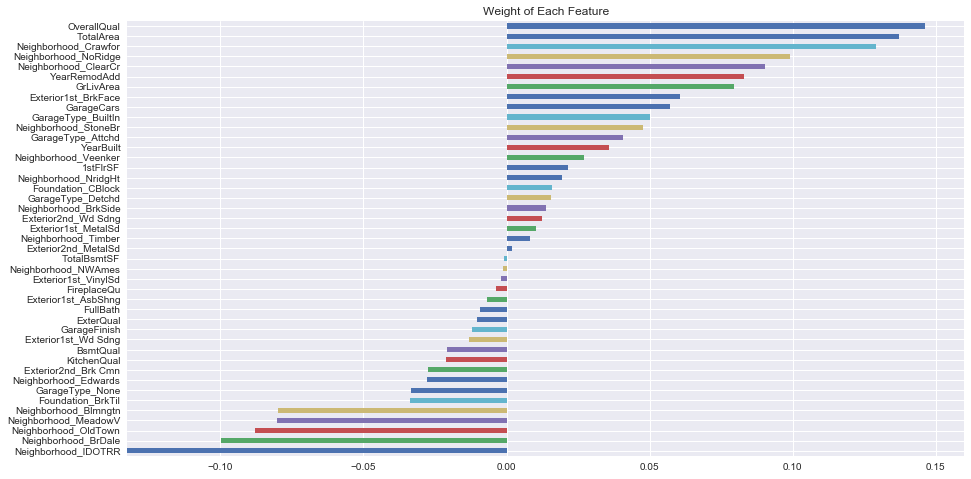

```python
#Visualize the features picked by Lasso
coefs = pd.Series(lasso.coef_, index = features_df.columns)
print("Lasso picked " + str(sum(coefs != 0)) + " features")
print("Lasso elminated " + str(sum(coefs == 0)) + " features")

plt.figure(figsize=(15,8))
coefs[coefs != 0].sort_values().plot(kind = "barh")
plt.title("Weight of Each Feature")
```

Comment:

- Even I did feature selection before modelling, Lasso still **eliminated 41 features**
  - Surprisingly, Lasso did not use TotRmsAbvGrd as a feature
  - **TotalArea is a good feature engineered**
  - **Neighborhood seems to be a really important feature** in predicting the SalePrice
- Therefore, **for the next model, I am going to input all features and feature engineer even more and let Lasso choose the best features**

## 7.4 L2 Regularization - Ridge

```python
#Tune the best alpha value again
ridge = RidgeCV(alphas=[5.1,5.2,5.3,5.4,5.5,5.6,5.7,5.8,5.9,6])
ridge.fit(X, y)
print("Best Alpha:", ridge.alpha_)
print("Lasso score: {:.4f}".format(rmsle_cv(ridge).mean()))
```

```
Best Alpha: 5.4
Lasso score: 0.1407
```

```
Ridge picked 84 features
Ridge elminated 0 features
```

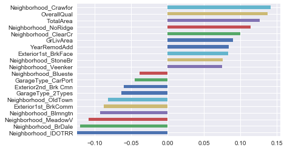

```python
coefs = pd.Series(ridge.coef_, index = features_df.columns)
print("Ridge picked " + str(sum(coefs != 0)) + " features")
print("Ridge elminated " + str(sum(coefs == 0)) + " features")

imp_coefs = pd.concat([coefs.sort_values().head(10),
                     coefs.sort_values().tail(10)])
imp_coefs.plot(kind = "barh")
```

Comment:

- As explained in Section 7. Modelling, **Ridge often uses all the features** due to the way its penalizing term is calculated
- Slight improve in score
- Seems to agree with Lasso on the importance of features
  - Neighborhood, OverallQual, TotalArea ... appeared again

## 7.5 RandomForest Model

- Use a **non-linear regression model for comparison**
- RandomForest chosen as it has become a benchmark for performance of models

```python
rf = RandomForestRegressor(random_state=1)
print("RandomForest score: {:.4f}".format(rmsle_cv(rf).mean()))
```

```
RandomForest score: 0.1565
```

Comment:

- **Linear regression models perform significantly better**
- This proves **Regularization should be used when dataset has many features such as Ames**

## 7.6 Take Average of Lasso and Ridge Predictions

- Normally, taking average of models will improve the score

```python
#Because we log our target, we must exponential the prediction back before submit to Kaggle
prediction = (np.expm1(lasso.predict(X_test)) + np.expm1(ridge.predict(X_test)))/2
submission = pd.DataFrame()
submission['Id'] = test_ID
submission['SalePrice'] = prediction
submission.to_csv('submission_house_model_1.csv',index=False)
```

## 7.6 Kaggle Submission

- **Kaggle scored 0.1498 which is higher than the cross validation scores above**
- This shows our model did not perform well on new Test Data
  - There is still some **degree of overfitting for our model**

[figure not shown]

## 7.7 Polynomial Regression

- I also came across Polynomial regression which **applies square, cubic, square root and etc to numeric features** to build a regression model to **better fit the given data**
  - y(x) = b + b1(x) + b2(x^2) b3(x^3) ...
  - x, x^2, x^3 are the same feature but applied with mathematical functions
  - b are coeffs of each feature after fitting the model
- So it really **depends on the insights you gained from the dataset and how you want to engineer the features to input into Regularization Models**
- One point to take note is **scaling become essential when you square or cubic features** because their values will become very large
- Reference: https://www.coursera.org/lecture/machine-learning/features-and-polynomial-regression-Rqgfz
- **However, I am not going to apply polynomial regression for this model as I only discovered polynomial regression at the modelling stage. I will try it at the next version**

# 8. Conclusion

- Although this model did not score better than the model built in Model 2, it really **provided me the opportunities to approach regression problems in a the systematic and analytic way**
- On my way building this model, I learnt and understood so many concepts such as **Data Correlation, Effects of Outliers, Normal Distribution, Skewness, Homoscedasticity, Log Transformation, Scaling, Linear Regression, L1 & L2 Regularization and Polynomial Regression**
  - It definitely provided me with strong foundation to build Model 2.

# References:

- https://www.kaggle.com/pmarcelino/comprehensive-data-exploration-with-python
- https://www.kaggle.com/serigne/stacked-regressions-top-4-on-leaderboard
- https://www.kaggle.com/vjgupta/reach-top-10-with-simple-model-on-housing-prices
- https://www.kaggle.com/apapiu/regularized-linear-models
- https://www.kaggle.com/juliencs/a-study-on-regression-applied-to-the-ames-dataset